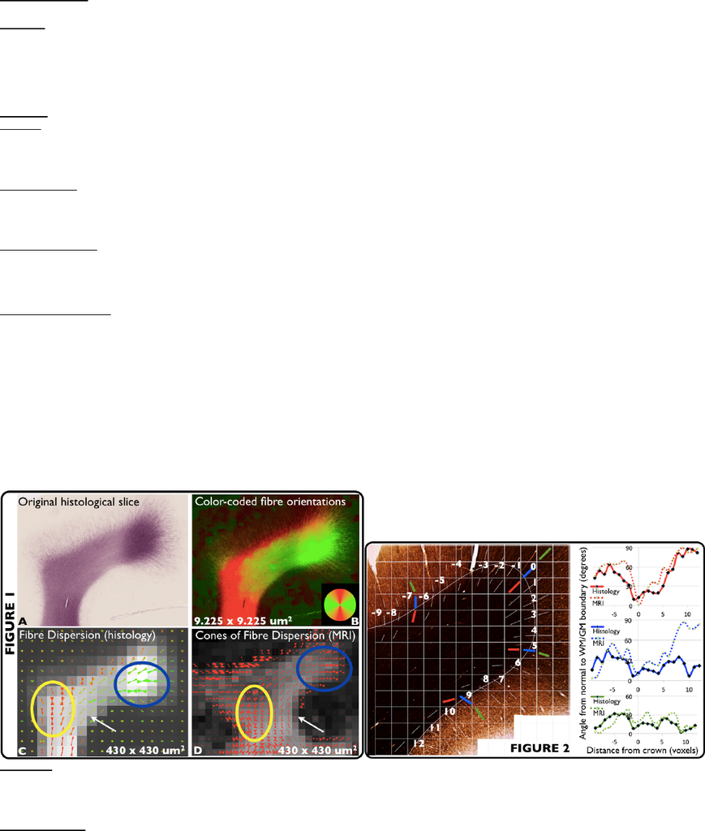

COMPARISON OF DIFFUSION MRI PREDICTIONS AND HISTOLOGY IN THE MACAQUE BRAIN

FMRIB Centre, University of Oxford, Oxford, Oxfodshire, United Kingdom,

Department of Anatomy & Neurobiology, Washington University, St Louis, MO, United